# ANCOVA in flow (prob. matemática) (flow (prob. matemática))

Geiser C. Challco geiser@alumni.usp.br

- Descriptive Statistics of Initial Data
- ANCOVA and Pairwise for one factor: **grupo**
  - Without remove non-normal data
  - Computing ANCOVA and PairWise After removing non-normal data (OK)
    - Plots for ancova
    - Checking linearity assumption
    - Checking normality and homogeneity
- ANCOVA and Pairwise for two factors **grupo:Sexo**
  - Without remove non-normal data
  - Computing ANCOVA and PairWise After removing non-normal data (OK)
    - Plots for ancova
    - Checking linearity assumption
    - Checking normality and homogeneity
- ANCOVA and Pairwise for two factors **grupo:Zona**
  - Without remove non-normal data
  - Computing ANCOVA and PairWise After removing non-normal data (OK)
    - Plots for ancova
    - Checking linearity assumption
    - Checking normality and homogeneity
- ANCOVA and Pairwise for two factors **grupo:Cor.Raca**
  - Without remove non-normal data
  - Computing ANCOVA and PairWise After removing non-normal data (OK)
    - Plots for ancova
    - Checking linearity assumption
    - Checking normality and homogeneity
- Summary of Results
  - Descriptive Statistics
  - ANCOVA Table Comparison
  - PairWise Table Comparison
  - EMMS Table Comparison

**NOTE**:

- Teste ANCOVA para determinar se houve diferenças significativas no flow (prob. matemática) (medido usando pre- e pos-testes).
- ANCOVA test to determine whether there were significant differences in flow (prob. matemática) (measured using pre- and post-tests).

# Descriptive Statistics of Initial Data

```r
df <- get.descriptives(dat, c(dv.pre, dv.pos), c("grupo"),
                       include.global = T, symmetry.test = T, normality.test = F)
df <- plyr::rbind.fill(
  df, do.call(plyr::rbind.fill, lapply(lfatores2, FUN = function(f) {
    if (nrow(dat) > 0 && sum(!is.na(unique(dat[[f]]))) > 1)
      get.descriptives(dat, c(dv.pre,dv.pos), c("grupo", f),
                       symmetry.test = T, normality.test = F)
    }))
)
(df <- df[,c(fatores1[fatores1 %in% colnames(df)],"variable",
             colnames(df)[!colnames(df) %in% c(fatores1,"variable")])])
```

```
##           grupo Sexo   Zona Cor.Raca       variable   n  mean median   min   max    sd    se    ci   iqr
## 1      Controle <NA>   <NA>     <NA> dfs.media.math 155 3.483  3.444 2.111 5.000 0.594 0.048 0.094 0.778
## 2  Experimental <NA>   <NA>     <NA> dfs.media.math 176 3.446  3.444 2.000 5.000 0.541 0.041 0.081 0.667
## 3          <NA> <NA>   <NA>     <NA> dfs.media.math 331 3.463  3.444 2.000 5.000 0.566 0.031 0.061 0.778
## 4      Controle <NA>   <NA>     <NA> fss.media.math 155 3.410  3.375 1.778 5.000 0.581 0.047 0.092 0.778
## 5  Experimental <NA>   <NA>     <NA> fss.media.math 176 3.362  3.333 1.111 4.667 0.539 0.041 0.080 0.667
## 6          <NA> <NA>   <NA>     <NA> fss.media.math 331 3.385  3.333 1.111 5.000 0.558 0.031 0.060 0.778
## 7      Controle    F   <NA>     <NA> dfs.media.math  73 3.474  3.444 2.111 4.667 0.596 0.070 0.139 1.000
## 8      Controle    M   <NA>     <NA> dfs.media.math  82 3.491  3.444 2.222 5.000 0.595 0.066 0.131 0.667
## 9  Experimental    F   <NA>     <NA> dfs.media.math  92 3.449  3.500 2.000 4.778 0.513 0.054 0.106 0.583
## 10 Experimental    M   <NA>     <NA> dfs.media.math  84 3.442  3.444 2.000 5.000 0.574 0.063 0.124 0.778
## 11     Controle    F   <NA>     <NA> fss.media.math  73 3.450  3.444 1.778 4.667 0.600 0.070 0.140 0.778
## 12     Controle    M   <NA>     <NA> fss.media.math  82 3.375  3.333 1.889 5.000 0.565 0.062 0.124 0.750
## 13 Experimental    F   <NA>     <NA> fss.media.math  92 3.348  3.333 2.000 4.444 0.512 0.053 0.106 0.778
## 14 Experimental    M   <NA>     <NA> fss.media.math  84 3.378  3.333 1.111 4.667 0.569 0.062 0.123 0.667
```

[output cut: 79 more lines]

| grupo | Sexo | Zona | Cor.Raca | variable | n | mean | median | min | max | sd | se | ci | iqr | symmetry | skewness | kurtosis |
| --- | --- | --- | --- | --- | --- | --- | --- | --- | --- | --- | --- | --- | --- | --- | --- | --- |
| Controle |  |  |  | dfs.media.math | 155 | 3.483 | 3.444 | 2.111 | 5.000 | 0.594 | 0.048 | 0.094 | 0.778 | YES | 0.175 | -0.356 |
| Experimental |  |  |  | dfs.media.math | 176 | 3.446 | 3.444 | 2.000 | 5.000 | 0.541 | 0.041 | 0.081 | 0.667 | YES | -0.104 | 0.119 |
|  |  |  |  | dfs.media.math | 331 | 3.463 | 3.444 | 2.000 | 5.000 | 0.566 | 0.031 | 0.061 | 0.778 | YES | 0.055 | -0.085 |
| Controle |  |  |  | fss.media.math | 155 | 3.410 | 3.375 | 1.778 | 5.000 | 0.581 | 0.047 | 0.092 | 0.778 | YES | 0.002 | 0.127 |
| Experimental |  |  |  | fss.media.math | 176 | 3.362 | 3.333 | 1.111 | 4.667 | 0.539 | 0.041 | 0.080 | 0.667 | YES | -0.286 | 1.048 |
|  |  |  |  | fss.media.math | 331 | 3.385 | 3.333 | 1.111 | 5.000 | 0.558 | 0.031 | 0.060 | 0.778 | YES | -0.126 | 0.609 |
| Controle | F |  |  | dfs.media.math | 73 | 3.474 | 3.444 | 2.111 | 4.667 | 0.596 | 0.070 | 0.139 | 1.000 | YES | -0.203 | -0.843 |
| Controle | M |  |  | dfs.media.math | 82 | 3.491 | 3.444 | 2.222 | 5.000 | 0.595 | 0.066 | 0.131 | 0.667 | NO | 0.511 | -0.022 |
| Experimental | F |  |  | dfs.media.math | 92 | 3.449 | 3.500 | 2.000 | 4.778 | 0.513 | 0.054 | 0.106 | 0.583 | YES | -0.230 | 0.269 |
| Experimental | M |  |  | dfs.media.math | 84 | 3.442 | 3.444 | 2.000 | 5.000 | 0.574 | 0.063 | 0.124 | 0.778 | YES | 0.000 | -0.107 |
| Controle | F |  |  | fss.media.math | 73 | 3.450 | 3.444 | 1.778 | 4.667 | 0.600 | 0.070 | 0.140 | 0.778 | YES | -0.278 | 0.036 |
| Controle | M |  |  | fss.media.math | 82 | 3.375 | 3.333 | 1.889 | 5.000 | 0.565 | 0.062 | 0.124 | 0.750 | YES | 0.275 | 0.276 |
| Experimental | F |  |  | fss.media.math | 92 | 3.348 | 3.333 | 2.000 | 4.444 | 0.512 | 0.053 | 0.106 | 0.778 | YES | -0.062 | -0.351 |
| Experimental | M |  |  | fss.media.math | 84 | 3.378 | 3.333 | 1.111 | 4.667 | 0.569 | 0.062 | 0.123 | 0.667 | YES | -0.474 | 1.948 |
| Controle |  | Rural |  | dfs.media.math | 104 | 3.551 | 3.500 | 2.333 | 5.000 | 0.570 | 0.056 | 0.111 | 0.778 | YES | 0.250 | -0.378 |
| Controle |  | Urbana |  | dfs.media.math | 30 | 3.522 | 3.500 | 2.333 | 4.778 | 0.642 | 0.117 | 0.240 | 0.861 | YES | 0.041 | -0.832 |
| Controle |  |  |  | dfs.media.math | 21 | 3.090 | 3.111 | 2.111 | 3.889 | 0.505 | 0.110 | 0.230 | 0.778 | YES | -0.159 | -0.949 |
| Experimental |  | Rural |  | dfs.media.math | 89 | 3.484 | 3.556 | 2.000 | 4.778 | 0.538 | 0.057 | 0.113 | 0.778 | NO | -0.516 | 0.252 |
| Experimental |  | Urbana |  | dfs.media.math | 41 | 3.393 | 3.222 | 2.667 | 4.556 | 0.544 | 0.085 | 0.172 | 0.778 | NO | 0.503 | -0.923 |
| Experimental |  |  |  | dfs.media.math | 46 | 3.420 | 3.389 | 2.000 | 5.000 | 0.551 | 0.081 | 0.164 | 0.444 | YES | 0.128 | 0.953 |
| Controle |  | Rural |  | fss.media.math | 104 | 3.455 | 3.444 | 1.778 | 4.778 | 0.579 | 0.057 | 0.113 | 0.806 | YES | -0.063 | -0.022 |
| Controle |  | Urbana |  | fss.media.math | 30 | 3.372 | 3.444 | 1.889 | 5.000 | 0.570 | 0.104 | 0.213 | 0.417 | YES | 0.044 | 1.474 |
| Controle |  |  |  | fss.media.math | 21 | 3.242 | 3.222 | 2.222 | 4.444 | 0.596 | 0.130 | 0.271 | 0.889 | YES | 0.263 | -0.953 |
| Experimental |  | Rural |  | fss.media.math | 89 | 3.454 | 3.444 | 2.333 | 4.667 | 0.466 | 0.049 | 0.098 | 0.667 | YES | 0.253 | -0.153 |
| Experimental |  | Urbana |  | fss.media.math | 41 | 3.184 | 3.111 | 1.111 | 4.444 | 0.617 | 0.096 | 0.195 | 0.444 | NO | -0.504 | 1.669 |
| Experimental |  |  |  | fss.media.math | 46 | 3.344 | 3.389 | 2.000 | 4.556 | 0.566 | 0.083 | 0.168 | 0.667 | YES | -0.172 | -0.453 |
| Controle |  |  | Branca | dfs.media.math | 20 | 3.489 | 3.389 | 2.333 | 5.000 | 0.675 | 0.151 | 0.316 | 0.917 | YES | 0.483 | -0.493 |
| Controle |  |  | Indígena | dfs.media.math | 3 | 3.778 | 4.000 | 3.333 | 4.000 | 0.385 | 0.222 | 0.956 | 0.333 | few data | 0.000 | 0.000 |
| Controle |  |  | Parda | dfs.media.math | 46 | 3.478 | 3.556 | 2.444 | 4.778 | 0.548 | 0.081 | 0.163 | 0.722 | YES | 0.094 | -0.634 |
| Controle |  |  | Preta | dfs.media.math | 1 | 3.444 | 3.444 | 3.444 | 3.444 |  |  |  | 0.000 | few data | 0.000 | 0.000 |
| Controle |  |  |  | dfs.media.math | 85 | 3.474 | 3.444 | 2.111 | 5.000 | 0.613 | 0.066 | 0.132 | 0.889 | YES | 0.133 | -0.449 |
| Experimental |  |  | Branca | dfs.media.math | 17 | 3.464 | 3.444 | 2.667 | 4.222 | 0.387 | 0.094 | 0.199 | 0.333 | YES | -0.255 | -0.257 |
| Experimental |  |  | Indígena | dfs.media.math | 13 | 3.544 | 3.625 | 2.778 | 4.000 | 0.383 | 0.106 | 0.231 | 0.556 | NO | -0.642 | -0.996 |
| Experimental |  |  | Parda | dfs.media.math | 45 | 3.330 | 3.444 | 2.222 | 4.333 | 0.539 | 0.080 | 0.162 | 0.778 | YES | -0.155 | -0.441 |
| Experimental |  |  | Preta | dfs.media.math | 1 | 3.222 | 3.222 | 3.222 | 3.222 |  |  |  | 0.000 | few data | 0.000 | 0.000 |
| Experimental |  |  |  | dfs.media.math | 100 | 3.485 | 3.444 | 2.000 | 5.000 | 0.581 | 0.058 | 0.115 | 0.778 | YES | -0.056 | 0.006 |
| Controle |  |  | Branca | fss.media.math | 20 | 3.550 | 3.556 | 2.556 | 4.444 | 0.544 | 0.122 | 0.254 | 0.806 | YES | -0.135 | -0.907 |
| Controle |  |  | Indígena | fss.media.math | 3 | 3.889 | 4.222 | 2.889 | 4.556 | 0.882 | 0.509 | 2.191 | 0.833 | few data | 0.000 | 0.000 |
| Controle |  |  | Parda | fss.media.math | 46 | 3.392 | 3.389 | 2.500 | 4.667 | 0.486 | 0.072 | 0.144 | 0.722 | YES | 0.137 | -0.563 |
| Controle |  |  | Preta | fss.media.math | 1 | 3.222 | 3.222 | 3.222 | 3.222 |  |  |  | 0.000 | few data | 0.000 | 0.000 |
| Controle |  |  |  | fss.media.math | 85 | 3.372 | 3.333 | 1.778 | 5.000 | 0.626 | 0.068 | 0.135 | 0.778 | YES | -0.011 | 0.246 |
| Experimental |  |  | Branca | fss.media.math | 17 | 3.471 | 3.444 | 2.333 | 4.667 | 0.618 | 0.150 | 0.318 | 0.875 | YES | 0.031 | -0.807 |
| Experimental |  |  | Indígena | fss.media.math | 13 | 3.265 | 3.222 | 2.778 | 3.889 | 0.373 | 0.103 | 0.225 | 0.556 | YES | 0.168 | -1.486 |
| Experimental |  |  | Parda | fss.media.math | 45 | 3.334 | 3.222 | 2.333 | 4.333 | 0.488 | 0.073 | 0.147 | 0.667 | YES | 0.130 | -0.700 |
| Experimental |  |  | Preta | fss.media.math | 1 | 3.889 | 3.889 | 3.889 | 3.889 |  |  |  | 0.000 | few data | 0.000 | 0.000 |
| Experimental |  |  |  | fss.media.math | 100 | 3.364 | 3.333 | 1.111 | 4.667 | 0.568 | 0.057 | 0.113 | 0.667 | NO | -0.531 | 1.603 |

# ANCOVA and Pairwise for one factor: **grupo**

## Without remove non-normal data

```r
pdat = remove_group_data(dat[!is.na(dat[["grupo"]]),], "fss.media.math", "grupo")

pdat.long <- rbind(pdat[,c("id","grupo")], pdat[,c("id","grupo")])
pdat.long[["time"]] <- c(rep("pre", nrow(pdat)), rep("pos", nrow(pdat)))
pdat.long[["time"]] <- factor(pdat.long[["time"]], c("pre","pos"))
pdat.long[["flow.math"]] <- c(pdat[["dfs.media.math"]], pdat[["fss.media.math"]])

aov = anova_test(pdat, fss.media.math ~ dfs.media.math + grupo)
laov[["grupo"]] <- get_anova_table(aov)
```

```r
pwc <- emmeans_test(pdat, fss.media.math ~ grupo, covariate = dfs.media.math,
                    p.adjust.method = "bonferroni")
```

```r
pwc.long <- emmeans_test(dplyr::group_by_at(pdat.long, "grupo"),
                          flow.math ~ time,
                          p.adjust.method = "bonferroni")
lpwc[["grupo"]] <- plyr::rbind.fill(pwc, pwc.long)
```

```r
ds <- get.descriptives(pdat, "fss.media.math", "grupo", covar = "dfs.media.math")
ds <- merge(ds[ds$variable != "dfs.media.math",],
            ds[ds$variable == "dfs.media.math", !colnames(ds) %in% c("variable")],
            by = "grupo", all.x = T, suffixes = c("", ".dfs.media.math"))
ds <- merge(get_emmeans(pwc), ds, by = "grupo", suffixes = c(".emms", ""))
ds <- ds[,c("grupo","n","mean.dfs.media.math","se.dfs.media.math","mean","se","emmean","se.emms")]

colnames(ds) <- c("grupo", "N", paste0(c("M","SE")," (pre)"),
                  paste0(c("M","SE"), " (unadj)"), paste0(c("M", "SE"), " (adj)"))

lemms[["grupo"]] <- ds
```

## Computing ANCOVA and PairWise After removing non-normal data (OK)

```r
wdat = pdat

res = residuals(lm(fss.media.math ~ dfs.media.math + grupo, data = wdat))
non.normal = getNonNormal(res, wdat$id, plimit = 0.05)

wdat = wdat[!wdat$id %in% non.normal,]

wdat.long <- rbind(wdat[,c("id","grupo")], wdat[,c("id","grupo")])
wdat.long[["time"]] <- c(rep("pre", nrow(wdat)), rep("pos", nrow(wdat)))
wdat.long[["time"]] <- factor(wdat.long[["time"]], c("pre","pos"))
wdat.long[["flow.math"]] <- c(wdat[["dfs.media.math"]], wdat[["fss.media.math"]])

ldat[["grupo"]] = wdat

(non.normal)
```

```
## [1] "P1772"
```

```r
aov = anova_test(wdat, fss.media.math ~ dfs.media.math + grupo)
laov[["grupo"]] <- merge(get_anova_table(aov), laov[["grupo"]], by="Effect", suffixes = c("","'"))

(df = get_anova_table(aov))
```

```
## ANOVA Table (type II tests)
##
##           Effect DFn DFd      F        p p<.05      ges
## 1 dfs.media.math   1 327 77.045 9.46e-17     * 0.191000
## 2          grupo   1 327  0.110 7.40e-01       0.000338
```

| Effect | DFn | DFd | F | p | p<.05 | ges |
| --- | --- | --- | --- | --- | --- | --- |
| dfs.media.math | 1 | 327 | 77.045 | 0.00 | * | 0.191 |
| grupo | 1 | 327 | 0.110 | 0.74 |  | 0.000 |

| term | .y. | group1 | group2 | df | statistic | p | p.adj | p.adj.signif |
| --- | --- | --- | --- | --- | --- | --- | --- | --- |
| dfs.media.math*grupo | fss.media.math | Controle | Experimental | 327 | 0.332 | 0.74 | 0.74 | ns |

```r
pwc.long <- emmeans_test(dplyr::group_by_at(wdat.long, "grupo"),
                         flow.math ~ time,
                         p.adjust.method = "bonferroni")
lpwc[["grupo"]] <- merge(plyr::rbind.fill(pwc, pwc.long), lpwc[["grupo"]], by=c("grupo","term",".y.","group1","group2"), suffixes = c("","'"))
```

| grupo | term | .y. | group1 | group2 | df | statistic | p | p.adj | p.adj.signif |
| --- | --- | --- | --- | --- | --- | --- | --- | --- | --- |
| Controle | time | flow.math | pre | pos | 656 | 1.147 | 0.252 | 0.252 | ns |
| Experimental | time | flow.math | pre | pos | 656 | 1.127 | 0.260 | 0.260 | ns |

```r
ds <- get.descriptives(wdat, "fss.media.math", "grupo", covar = "dfs.media.math")
ds <- merge(ds[ds$variable != "dfs.media.math",],
            ds[ds$variable == "dfs.media.math", !colnames(ds) %in% c("variable")],
            by = "grupo", all.x = T, suffixes = c("", ".dfs.media.math"))
ds <- merge(get_emmeans(pwc), ds, by = "grupo", suffixes = c(".emms", ""))
ds <- ds[,c("grupo","n","mean.dfs.media.math","se.dfs.media.math","mean","se","emmean","se.emms")]

colnames(ds) <- c("grupo", "N", paste0(c("M","SE")," (pre)"),
                  paste0(c("M","SE"), " (unadj)"), paste0(c("M", "SE"), " (adj)"))

lemms[["grupo"]] <- merge(ds, lemms[["grupo"]], by=c("grupo"), suffixes = c("","'"))
```

| grupo | N | M (pre) | SE (pre) | M (unadj) | SE (unadj) | M (adj) | SE (adj) |
| --- | --- | --- | --- | --- | --- | --- | --- |
| Controle | 155 | 3.483 | 0.048 | 3.410 | 0.047 | 3.401 | 0.039 |
| Experimental | 175 | 3.442 | 0.041 | 3.375 | 0.039 | 3.383 | 0.037 |

### Plots for ancova

```r
plots <- oneWayAncovaPlots(
  wdat, "fss.media.math", "grupo", aov, list("grupo"=pwc), addParam = c("mean_se"),
  font.label.size=10, step.increase=0.05, p.label="p.adj",
  subtitle = which(aov$Effect == "grupo"))
```

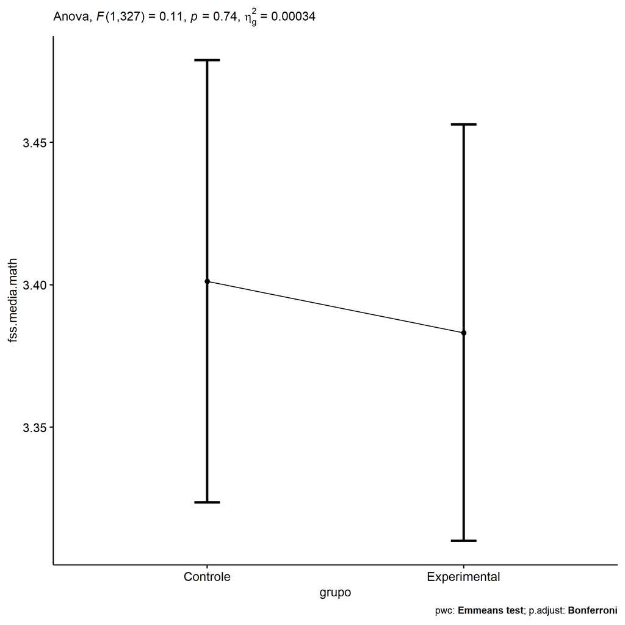

```r
if (!is.null(nrow(plots[["grupo"]]$data)))
  plots[["grupo"]] + ggplot2::scale_color_manual(values = color[["grupo"]])
```

```r
plots <- oneWayAncovaBoxPlots(
  wdat, "fss.media.math", "grupo", aov, pwc, covar = "dfs.media.math",
  theme = "classic", color = color[["grupo"]],
  subtitle = which(aov$Effect == "grupo"))
```

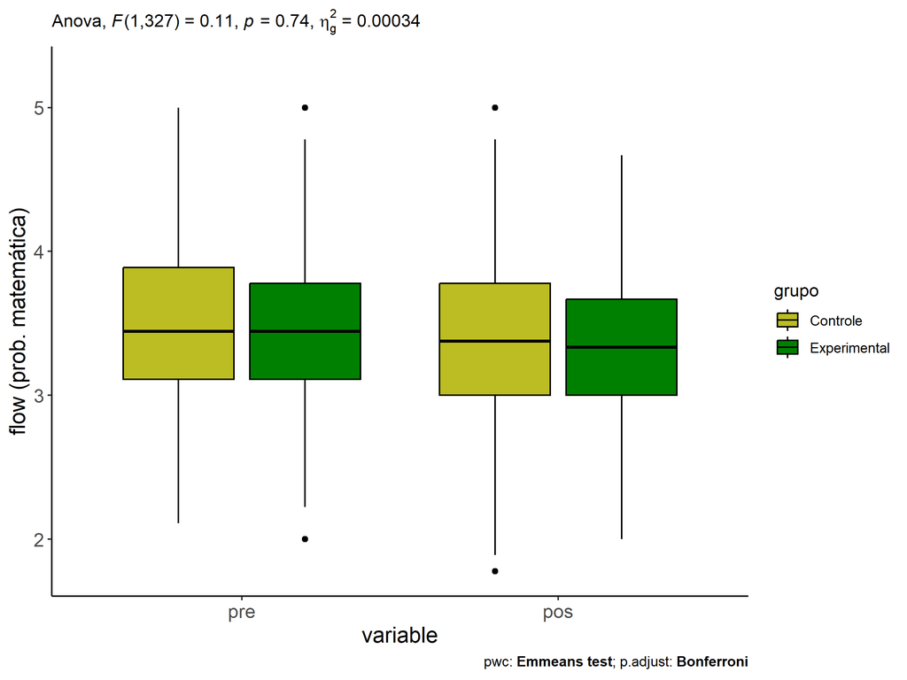

```r
if (length(unique(wdat[["grupo"]])) > 1)
  plots[["grupo"]] + ggplot2::ylab("flow (prob. matemática)") + ggplot2::scale_x_discrete(labels=c('pre', 'pos'))
```

```r
if (length(unique(wdat.long[["grupo"]])) > 1)
  plots <- oneWayAncovaBoxPlots(
    wdat.long, "flow.math", "grupo", aov, pwc.long, pre.post = "time",
    theme = "classic", color = color$prepost)
```

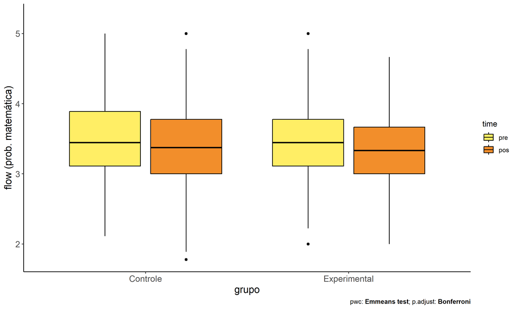

```r
if (length(unique(wdat.long[["grupo"]])) > 1)
  plots[["grupo"]] + ggplot2::ylab("flow (prob. matemática)")
```

### Checking linearity assumption

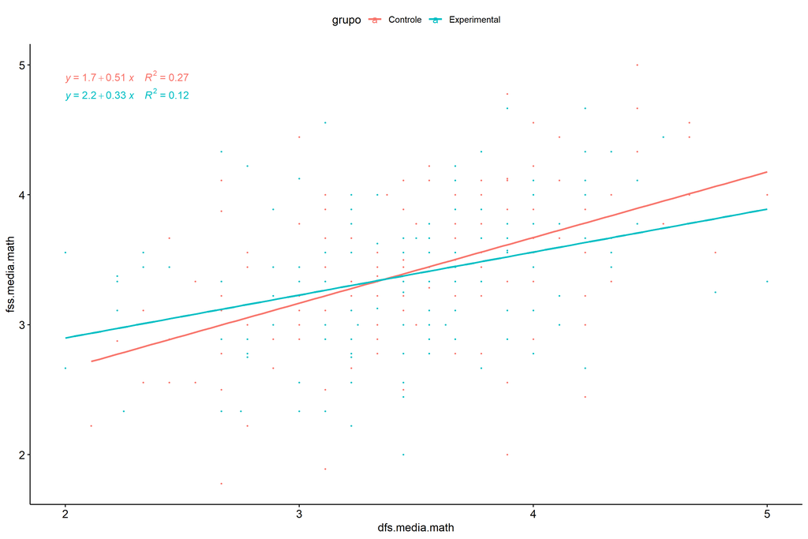

```r
ggscatter(wdat, x = "dfs.media.math", y = "fss.media.math", size = 0.5,
          color = "grupo", add = "reg.line")+
  stat_regline_equation(
    aes(label =  paste(..eq.label.., ..rr.label.., sep = "~~~~"), color = grupo)
  )
```

### Checking normality and homogeneity

```r
res <- augment(lm(fss.media.math ~ dfs.media.math + grupo, data = wdat))
```

```r
shapiro_test(res$.resid)
```

```
## # A tibble: 1 × 3
##   variable   statistic p.value
##   <chr>          <dbl>   <dbl>
## 1 res$.resid     0.996   0.514
```

```r
levene_test(res, .resid ~ grupo)
```

```
## # A tibble: 1 × 4
##     df1   df2 statistic     p
##   <int> <int>     <dbl> <dbl>
## 1     1   328    0.0354 0.851
```

# ANCOVA and Pairwise for two factors **grupo:Sexo**

## Without remove non-normal data

```r
pdat = remove_group_data(dat[!is.na(dat[["grupo"]]) & !is.na(dat[["Sexo"]]),], "fss.media.math", c("grupo","Sexo"))

pdat.long <- rbind(pdat[,c("id","grupo","Sexo")], pdat[,c("id","grupo","Sexo")])
pdat.long[["time"]] <- c(rep("pre", nrow(pdat)), rep("pos", nrow(pdat)))
pdat.long[["time"]] <- factor(pdat.long[["time"]], c("pre","pos"))
pdat.long[["flow.math"]] <- c(pdat[["dfs.media.math"]], pdat[["fss.media.math"]])

aov = anova_test(pdat, fss.media.math ~ dfs.media.math + grupo*Sexo)
laov[["grupo:Sexo"]] <- get_anova_table(aov)
```

```r
pwcs <- list()
pwcs[["Sexo"]] <- emmeans_test(
  group_by(pdat, grupo), fss.media.math ~ Sexo,
  covariate = dfs.media.math, p.adjust.method = "bonferroni")
pwcs[["grupo"]] <- emmeans_test(
  group_by(pdat, Sexo), fss.media.math ~ grupo,
  covariate = dfs.media.math, p.adjust.method = "bonferroni")

pwc <- plyr::rbind.fill(pwcs[["grupo"]], pwcs[["Sexo"]])
pwc <- pwc[,c("grupo","Sexo", colnames(pwc)[!colnames(pwc) %in% c("grupo","Sexo")])]
```

```r
pwc.long <- emmeans_test(dplyr::group_by_at(pdat.long, c("grupo","Sexo")),
                         flow.math ~ time,
                         p.adjust.method = "bonferroni")
lpwc[["grupo:Sexo"]] <- plyr::rbind.fill(pwc, pwc.long)
```

```r
ds <- get.descriptives(pdat, "fss.media.math", c("grupo","Sexo"), covar = "dfs.media.math")
ds <- merge(ds[ds$variable != "dfs.media.math",],
            ds[ds$variable == "dfs.media.math", !colnames(ds) %in% c("variable")],
            by = c("grupo","Sexo"), all.x = T, suffixes = c("", ".dfs.media.math"))
ds <- merge(get_emmeans(pwcs[["grupo"]]), ds, by = c("grupo","Sexo"), suffixes = c(".emms", ""))
ds <- ds[,c("grupo","Sexo","n","mean.dfs.media.math","se.dfs.media.math","mean","se","emmean","se.emms")]

colnames(ds) <- c("grupo","Sexo", "N", paste0(c("M","SE")," (pre)"),
                  paste0(c("M","SE"), " (unadj)"), paste0(c("M", "SE"), " (adj)"))

lemms[["grupo:Sexo"]] <- ds
```

## Computing ANCOVA and PairWise After removing non-normal data (OK)

```r
wdat = pdat

res = residuals(lm(fss.media.math ~ dfs.media.math + grupo*Sexo, data = wdat))
non.normal = getNonNormal(res, wdat$id, plimit = 0.05)

wdat = wdat[!wdat$id %in% non.normal,]

wdat.long <- rbind(wdat[,c("id","grupo","Sexo")], wdat[,c("id","grupo","Sexo")])
wdat.long[["time"]] <- c(rep("pre", nrow(wdat)), rep("pos", nrow(wdat)))
wdat.long[["time"]] <- factor(wdat.long[["time"]], c("pre","pos"))
wdat.long[["flow.math"]] <- c(wdat[["dfs.media.math"]], wdat[["fss.media.math"]])


ldat[["grupo:Sexo"]] = wdat

(non.normal)
```

```
## [1] "P1772"
```

```r
aov = anova_test(wdat, fss.media.math ~ dfs.media.math + grupo*Sexo)
laov[["grupo:Sexo"]] <- merge(get_anova_table(aov), laov[["grupo:Sexo"]], by="Effect", suffixes = c("","'"))

(df = get_anova_table(aov))
```

```
## ANOVA Table (type II tests)
##
##           Effect DFn DFd      F        p p<.05      ges
## 1 dfs.media.math   1 325 77.325 8.62e-17     * 1.92e-01
## 2          grupo   1 325  0.113 7.37e-01       3.48e-04
## 3           Sexo   1 325  0.008 9.30e-01       2.35e-05
## 4     grupo:Sexo   1 325  1.833 1.77e-01       6.00e-03
```

| Effect | DFn | DFd | F | p | p<.05 | ges |
| --- | --- | --- | --- | --- | --- | --- |
| dfs.media.math | 1 | 325 | 77.325 | 0.000 | * | 0.192 |
| grupo | 1 | 325 | 0.113 | 0.737 |  | 0.000 |
| Sexo | 1 | 325 | 0.008 | 0.930 |  | 0.000 |
| grupo:Sexo | 1 | 325 | 1.833 | 0.177 |  | 0.006 |

```r
pwcs <- list()
pwcs[["Sexo"]] <- emmeans_test(
  group_by(wdat, grupo), fss.media.math ~ Sexo,
  covariate = dfs.media.math, p.adjust.method = "bonferroni")
pwcs[["grupo"]] <- emmeans_test(
  group_by(wdat, Sexo), fss.media.math ~ grupo,
  covariate = dfs.media.math, p.adjust.method = "bonferroni")

pwc <- plyr::rbind.fill(pwcs[["grupo"]], pwcs[["Sexo"]])
pwc <- pwc[,c("grupo","Sexo", colnames(pwc)[!colnames(pwc) %in% c("grupo","Sexo")])]
```

| grupo | Sexo | term | .y. | group1 | group2 | df | statistic | p | p.adj | p.adj.signif |
| --- | --- | --- | --- | --- | --- | --- | --- | --- | --- | --- |
|  | F | dfs.media.math*grupo | fss.media.math | Controle | Experimental | 325 | 1.197 | 0.232 | 0.232 | ns |
|  | M | dfs.media.math*grupo | fss.media.math | Controle | Experimental | 325 | -0.715 | 0.475 | 0.475 | ns |
| Controle |  | dfs.media.math*Sexo | fss.media.math | F | M | 325 | 1.046 | 0.296 | 0.296 | ns |
| Experimental |  | dfs.media.math*Sexo | fss.media.math | F | M | 325 | -0.864 | 0.388 | 0.388 | ns |

```r
pwc.long <- emmeans_test(dplyr::group_by_at(wdat.long, c("grupo","Sexo")),
                         flow.math ~ time,
                         p.adjust.method = "bonferroni")
lpwc[["grupo:Sexo"]] <- merge(plyr::rbind.fill(pwc, pwc.long), lpwc[["grupo:Sexo"]], by=c("grupo","Sexo","term",".y.","group1","group2"), suffixes = c("","'"))
```

| grupo | Sexo | term | .y. | group1 | group2 | df | statistic | p | p.adj | p.adj.signif |
| --- | --- | --- | --- | --- | --- | --- | --- | --- | --- | --- |
| Controle | F | time | flow.math | pre | pos | 652 | 0.256 | 0.798 | 0.798 | ns |
| Controle | M | time | flow.math | pre | pos | 652 | 1.332 | 0.183 | 0.183 | ns |
| Experimental | F | time | flow.math | pre | pos | 652 | 1.237 | 0.217 | 0.217 | ns |
| Experimental | M | time | flow.math | pre | pos | 652 | 0.331 | 0.741 | 0.741 | ns |

```r
ds <- get.descriptives(wdat, "fss.media.math", c("grupo","Sexo"), covar = "dfs.media.math")
ds <- merge(ds[ds$variable != "dfs.media.math",],
            ds[ds$variable == "dfs.media.math", !colnames(ds) %in% c("variable")],
            by = c("grupo","Sexo"), all.x = T, suffixes = c("", ".dfs.media.math"))
ds <- merge(get_emmeans(pwcs[["grupo"]]), ds, by = c("grupo","Sexo"), suffixes = c(".emms", ""))
ds <- ds[,c("grupo","Sexo","n","mean.dfs.media.math","se.dfs.media.math","mean","se","emmean","se.emms")]

colnames(ds) <- c("grupo","Sexo", "N", paste0(c("M","SE")," (pre)"),
                  paste0(c("M","SE"), " (unadj)"), paste0(c("M", "SE"), " (adj)"))

lemms[["grupo:Sexo"]] <- merge(ds, lemms[["grupo:Sexo"]], by=c("grupo","Sexo"), suffixes = c("","'"))
```

| grupo | Sexo | N | M (pre) | SE (pre) | M (unadj) | SE (unadj) | M (adj) | SE (adj) |
| --- | --- | --- | --- | --- | --- | --- | --- | --- |
| Controle | F | 73 | 3.474 | 0.070 | 3.450 | 0.070 | 3.445 | 0.058 |
| Controle | M | 82 | 3.491 | 0.066 | 3.375 | 0.062 | 3.362 | 0.054 |
| Experimental | F | 92 | 3.449 | 0.054 | 3.348 | 0.053 | 3.353 | 0.051 |
| Experimental | M | 83 | 3.434 | 0.063 | 3.406 | 0.056 | 3.417 | 0.054 |

### Plots for ancova

```r
plots <- twoWayAncovaPlots(
  wdat, "fss.media.math", c("grupo","Sexo"), aov, pwcs, addParam = c("mean_se"),
  font.label.size=10, step.increase=0.05, p.label="p.adj",
  subtitle = which(aov$Effect == "grupo:Sexo"))
```

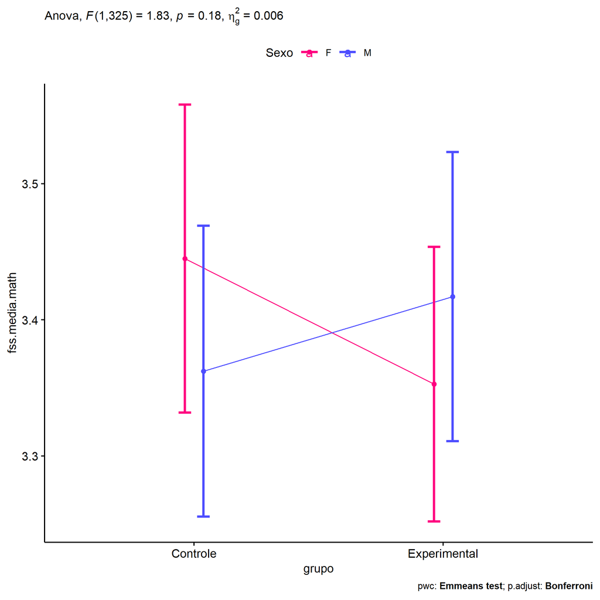

```r
if (!is.null(plots[["grupo"]]))
  plots[["grupo"]] + ggplot2::scale_color_manual(values = color[["Sexo"]])
```

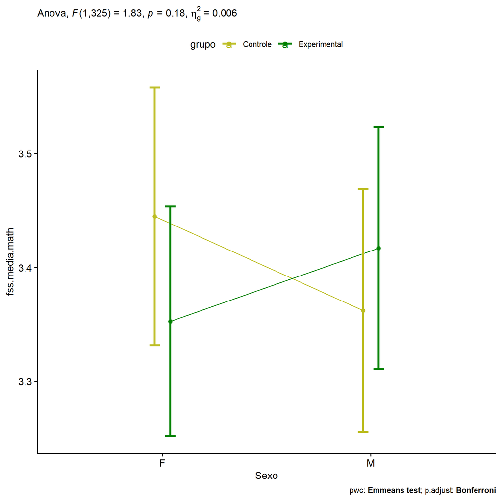

```r
if (!is.null(plots[["Sexo"]]))
  plots[["Sexo"]] + ggplot2::scale_color_manual(values = color[["grupo"]])
```

```r
plots <- twoWayAncovaBoxPlots(
  wdat, "fss.media.math", c("grupo","Sexo"), aov, pwcs, covar = "dfs.media.math",
  theme = "classic", color = color[["grupo:Sexo"]],
  subtitle = which(aov$Effect == "grupo:Sexo"))
```

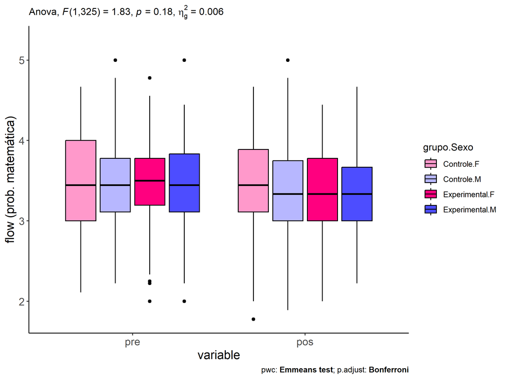

```r
plots[["grupo:Sexo"]] + ggplot2::ylab("flow (prob. matemática)") + ggplot2::scale_x_discrete(labels=c('pre', 'pos'))
```

```r
plots <- twoWayAncovaBoxPlots(
  wdat.long, "flow.math", c("grupo","Sexo"), aov, pwc.long, pre.post = "time",
  theme = "classic", color = color$prepost)
```

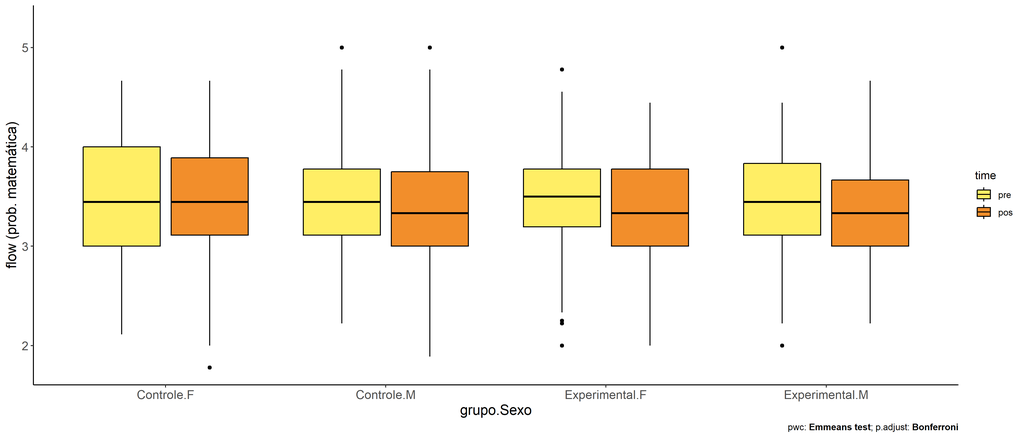

```r
plots[["grupo:Sexo"]] + ggplot2::ylab("flow (prob. matemática)")
```

### Checking linearity assumption

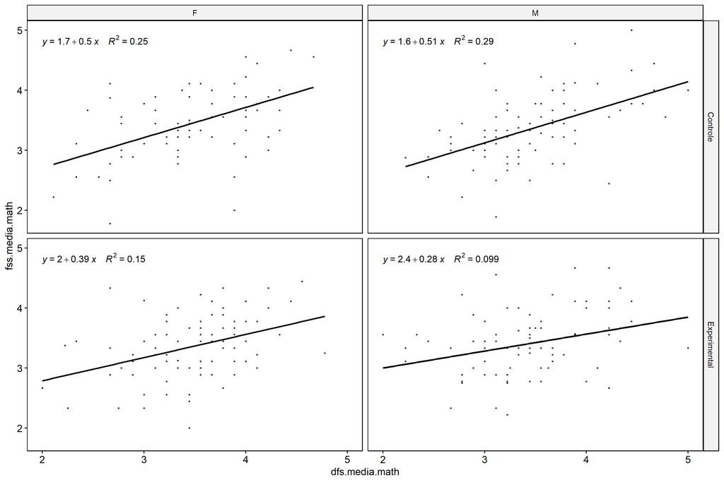

```r
ggscatter(wdat, x = "dfs.media.math", y = "fss.media.math", size = 0.5,
          facet.by = c("grupo","Sexo"), add = "reg.line")+
  stat_regline_equation(
    aes(label =  paste(..eq.label.., ..rr.label.., sep = "~~~~"))
  )
```

### Checking normality and homogeneity

```r
res <- augment(lm(fss.media.math ~ dfs.media.math + grupo*Sexo, data = wdat))
```

```r
shapiro_test(res$.resid)
```

```
## # A tibble: 1 × 3
##   variable   statistic p.value
##   <chr>          <dbl>   <dbl>
## 1 res$.resid     0.996   0.476
```

```r
levene_test(res, .resid ~ grupo*Sexo)
```

```
## # A tibble: 1 × 4
##     df1   df2 statistic     p
##   <int> <int>     <dbl> <dbl>
## 1     3   326     0.541 0.655
```

# ANCOVA and Pairwise for two factors **grupo:Zona**

## Without remove non-normal data

```r
pdat = remove_group_data(dat[!is.na(dat[["grupo"]]) & !is.na(dat[["Zona"]]),], "fss.media.math", c("grupo","Zona"))

pdat.long <- rbind(pdat[,c("id","grupo","Zona")], pdat[,c("id","grupo","Zona")])
pdat.long[["time"]] <- c(rep("pre", nrow(pdat)), rep("pos", nrow(pdat)))
pdat.long[["time"]] <- factor(pdat.long[["time"]], c("pre","pos"))
pdat.long[["flow.math"]] <- c(pdat[["dfs.media.math"]], pdat[["fss.media.math"]])

aov = anova_test(pdat, fss.media.math ~ dfs.media.math + grupo*Zona)
laov[["grupo:Zona"]] <- get_anova_table(aov)
```

```r
pwcs <- list()
pwcs[["Zona"]] <- emmeans_test(
  group_by(pdat, grupo), fss.media.math ~ Zona,
  covariate = dfs.media.math, p.adjust.method = "bonferroni")
pwcs[["grupo"]] <- emmeans_test(
  group_by(pdat, Zona), fss.media.math ~ grupo,
  covariate = dfs.media.math, p.adjust.method = "bonferroni")

pwc <- plyr::rbind.fill(pwcs[["grupo"]], pwcs[["Zona"]])
pwc <- pwc[,c("grupo","Zona", colnames(pwc)[!colnames(pwc) %in% c("grupo","Zona")])]
```

```r
pwc.long <- emmeans_test(dplyr::group_by_at(pdat.long, c("grupo","Zona")),
                         flow.math ~ time,
                         p.adjust.method = "bonferroni")
lpwc[["grupo:Zona"]] <- plyr::rbind.fill(pwc, pwc.long)
```

```r
ds <- get.descriptives(pdat, "fss.media.math", c("grupo","Zona"), covar = "dfs.media.math")
ds <- merge(ds[ds$variable != "dfs.media.math",],
            ds[ds$variable == "dfs.media.math", !colnames(ds) %in% c("variable")],
            by = c("grupo","Zona"), all.x = T, suffixes = c("", ".dfs.media.math"))
ds <- merge(get_emmeans(pwcs[["grupo"]]), ds, by = c("grupo","Zona"), suffixes = c(".emms", ""))
ds <- ds[,c("grupo","Zona","n","mean.dfs.media.math","se.dfs.media.math","mean","se","emmean","se.emms")]

colnames(ds) <- c("grupo","Zona", "N", paste0(c("M","SE")," (pre)"),
                  paste0(c("M","SE"), " (unadj)"), paste0(c("M", "SE"), " (adj)"))

lemms[["grupo:Zona"]] <- ds
```

## Computing ANCOVA and PairWise After removing non-normal data (OK)

```r
wdat = pdat

res = residuals(lm(fss.media.math ~ dfs.media.math + grupo*Zona, data = wdat))
non.normal = getNonNormal(res, wdat$id, plimit = 0.05)

wdat = wdat[!wdat$id %in% non.normal,]

wdat.long <- rbind(wdat[,c("id","grupo","Zona")], wdat[,c("id","grupo","Zona")])
wdat.long[["time"]] <- c(rep("pre", nrow(wdat)), rep("pos", nrow(wdat)))
wdat.long[["time"]] <- factor(wdat.long[["time"]], c("pre","pos"))
wdat.long[["flow.math"]] <- c(wdat[["dfs.media.math"]], wdat[["fss.media.math"]])


ldat[["grupo:Zona"]] = wdat

(non.normal)
```

```
## [1] "P1772"
```

```r
aov = anova_test(wdat, fss.media.math ~ dfs.media.math + grupo*Zona)
laov[["grupo:Zona"]] <- merge(get_anova_table(aov), laov[["grupo:Zona"]], by="Effect", suffixes = c("","'"))

(df = get_anova_table(aov))
```

```
## ANOVA Table (type II tests)
##
##           Effect DFn DFd         F        p p<.05      ges
## 1 dfs.media.math   1 258 69.656000 4.32e-15     * 2.13e-01
## 2          grupo   1 258  0.000831 9.77e-01       3.22e-06
## 3           Zona   1 258  3.512000 6.20e-02       1.30e-02
## 4     grupo:Zona   1 258  0.552000 4.58e-01       2.00e-03
```

| Effect | DFn | DFd | F | p | p<.05 | ges |
| --- | --- | --- | --- | --- | --- | --- |
| dfs.media.math | 1 | 258 | 69.656 | 0.000 | * | 0.213 |
| grupo | 1 | 258 | 0.001 | 0.977 |  | 0.000 |
| Zona | 1 | 258 | 3.512 | 0.062 |  | 0.013 |
| grupo:Zona | 1 | 258 | 0.552 | 0.458 |  | 0.002 |

```r
pwcs <- list()
pwcs[["Zona"]] <- emmeans_test(
  group_by(wdat, grupo), fss.media.math ~ Zona,
  covariate = dfs.media.math, p.adjust.method = "bonferroni")
pwcs[["grupo"]] <- emmeans_test(
  group_by(wdat, Zona), fss.media.math ~ grupo,
  covariate = dfs.media.math, p.adjust.method = "bonferroni")

pwc <- plyr::rbind.fill(pwcs[["grupo"]], pwcs[["Zona"]])
pwc <- pwc[,c("grupo","Zona", colnames(pwc)[!colnames(pwc) %in% c("grupo","Zona")])]
```

| grupo | Zona | term | .y. | group1 | group2 | df | statistic | p | p.adj | p.adj.signif |
| --- | --- | --- | --- | --- | --- | --- | --- | --- | --- | --- |
|  | Rural | dfs.media.math*grupo | fss.media.math | Controle | Experimental | 258 | -0.404 | 0.686 | 0.686 | ns |
|  | Urbana | dfs.media.math*grupo | fss.media.math | Controle | Experimental | 258 | 0.623 | 0.534 | 0.534 | ns |
| Controle |  | dfs.media.math*Zona | fss.media.math | Rural | Urbana | 258 | 0.723 | 0.470 | 0.470 | ns |
| Experimental |  | dfs.media.math*Zona | fss.media.math | Rural | Urbana | 258 | 1.883 | 0.061 | 0.061 | ns |

```r
pwc.long <- emmeans_test(dplyr::group_by_at(wdat.long, c("grupo","Zona")),
                         flow.math ~ time,
                         p.adjust.method = "bonferroni")
lpwc[["grupo:Zona"]] <- merge(plyr::rbind.fill(pwc, pwc.long), lpwc[["grupo:Zona"]], by=c("grupo","Zona","term",".y.","group1","group2"), suffixes = c("","'"))
```

| grupo | Zona | term | .y. | group1 | group2 | df | statistic | p | p.adj | p.adj.signif |
| --- | --- | --- | --- | --- | --- | --- | --- | --- | --- | --- |
| Controle | Rural | time | flow.math | pre | pos | 518 | 1.251 | 0.211 | 0.211 | ns |
| Controle | Urbana | time | flow.math | pre | pos | 518 | 1.061 | 0.289 | 0.289 | ns |
| Experimental | Rural | time | flow.math | pre | pos | 518 | 0.362 | 0.717 | 0.717 | ns |
| Experimental | Urbana | time | flow.math | pre | pos | 518 | 1.134 | 0.257 | 0.257 | ns |

```r
ds <- get.descriptives(wdat, "fss.media.math", c("grupo","Zona"), covar = "dfs.media.math")
ds <- merge(ds[ds$variable != "dfs.media.math",],
            ds[ds$variable == "dfs.media.math", !colnames(ds) %in% c("variable")],
            by = c("grupo","Zona"), all.x = T, suffixes = c("", ".dfs.media.math"))
ds <- merge(get_emmeans(pwcs[["grupo"]]), ds, by = c("grupo","Zona"), suffixes = c(".emms", ""))
ds <- ds[,c("grupo","Zona","n","mean.dfs.media.math","se.dfs.media.math","mean","se","emmean","se.emms")]

colnames(ds) <- c("grupo","Zona", "N", paste0(c("M","SE")," (pre)"),
                  paste0(c("M","SE"), " (unadj)"), paste0(c("M", "SE"), " (adj)"))

lemms[["grupo:Zona"]] <- merge(ds, lemms[["grupo:Zona"]], by=c("grupo","Zona"), suffixes = c("","'"))
```

| grupo | Zona | N | M (pre) | SE (pre) | M (unadj) | SE (unadj) | M (adj) | SE (adj) |
| --- | --- | --- | --- | --- | --- | --- | --- | --- |
| Controle | Rural | 104 | 3.551 | 0.056 | 3.455 | 0.057 | 3.432 | 0.047 |
| Controle | Urbana | 30 | 3.522 | 0.117 | 3.372 | 0.104 | 3.361 | 0.087 |
| Experimental | Rural | 89 | 3.484 | 0.057 | 3.454 | 0.049 | 3.460 | 0.050 |
| Experimental | Urbana | 40 | 3.375 | 0.085 | 3.236 | 0.083 | 3.290 | 0.075 |

### Plots for ancova

```r
plots <- twoWayAncovaPlots(
  wdat, "fss.media.math", c("grupo","Zona"), aov, pwcs, addParam = c("mean_se"),
  font.label.size=10, step.increase=0.05, p.label="p.adj",
  subtitle = which(aov$Effect == "grupo:Zona"))
```

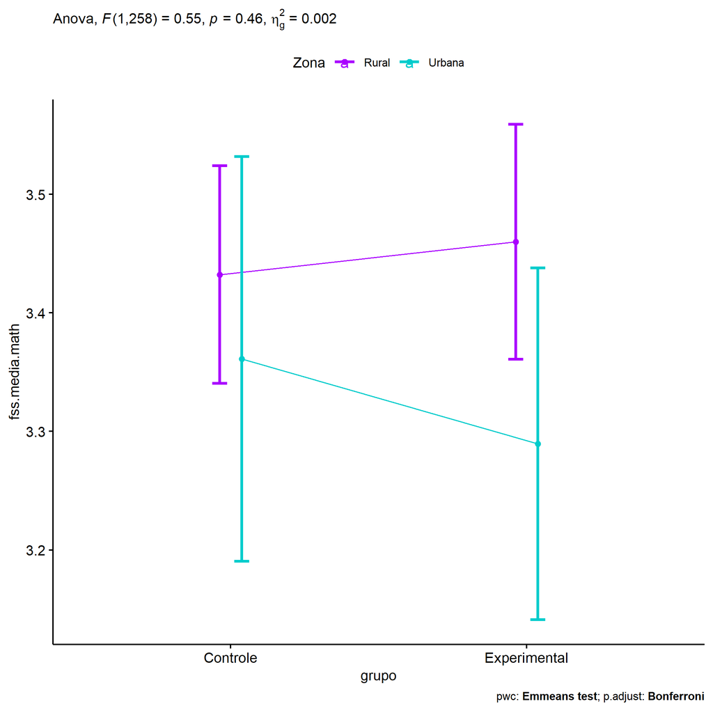

```r
if (!is.null(plots[["grupo"]]))
  plots[["grupo"]] + ggplot2::scale_color_manual(values = color[["Zona"]])
```

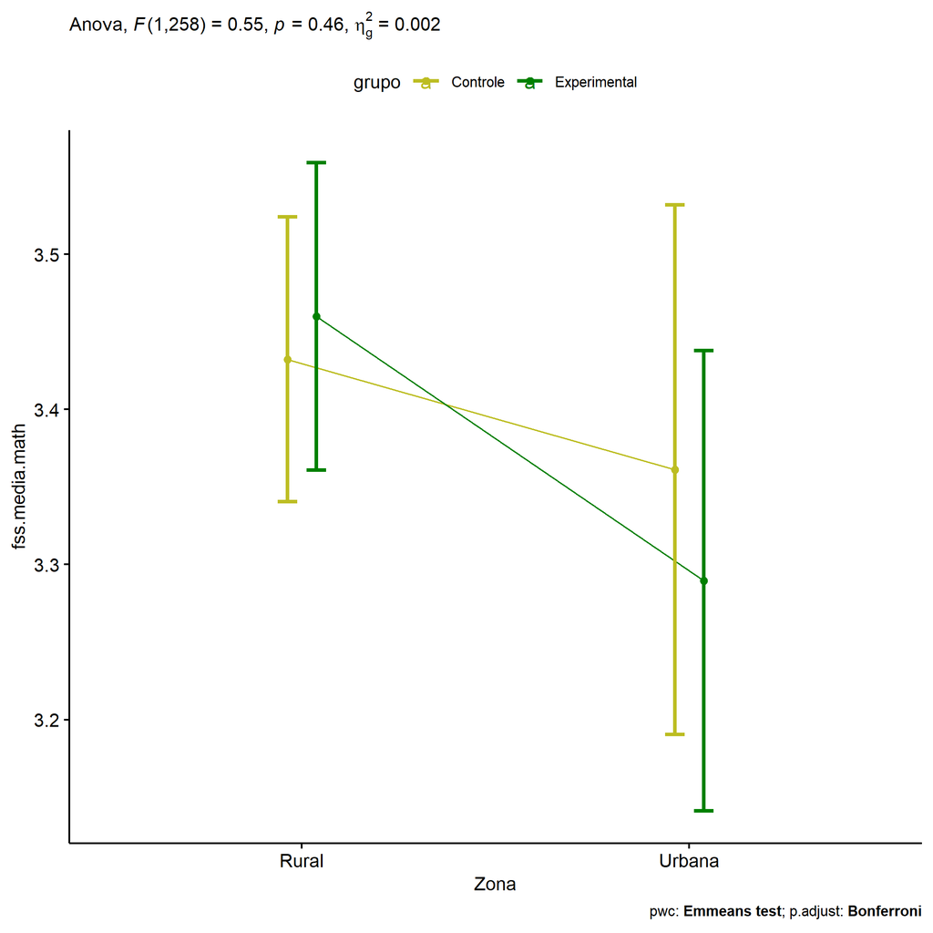

```r
if (!is.null(plots[["Zona"]]))
  plots[["Zona"]] + ggplot2::scale_color_manual(values = color[["grupo"]])
```

```r
plots <- twoWayAncovaBoxPlots(
  wdat, "fss.media.math", c("grupo","Zona"), aov, pwcs, covar = "dfs.media.math",
  theme = "classic", color = color[["grupo:Zona"]],
  subtitle = which(aov$Effect == "grupo:Zona"))
```

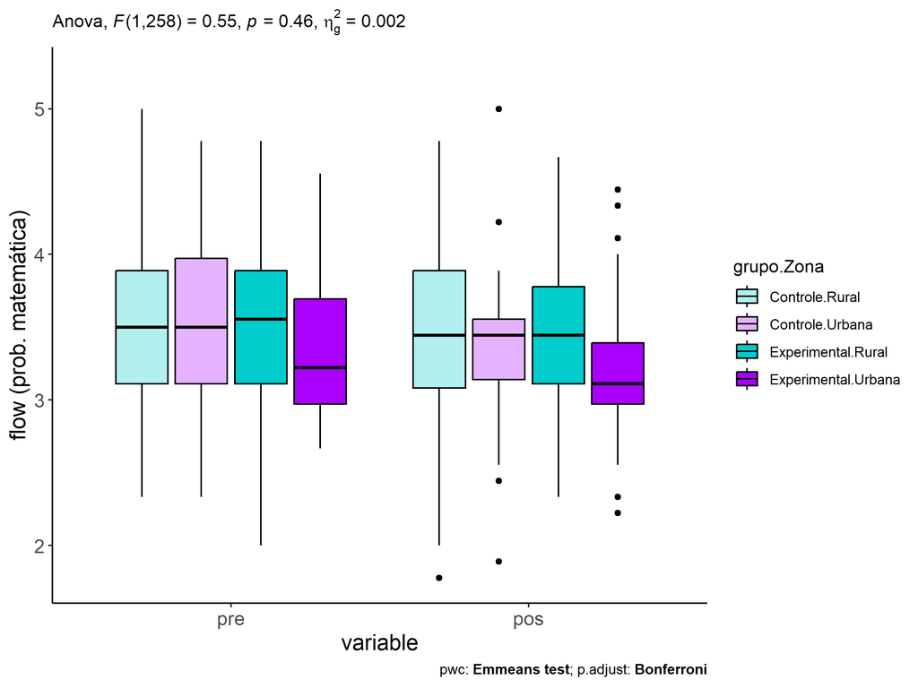

```r
plots[["grupo:Zona"]] + ggplot2::ylab("flow (prob. matemática)") + ggplot2::scale_x_discrete(labels=c('pre', 'pos'))
```

```r
plots <- twoWayAncovaBoxPlots(
  wdat.long, "flow.math", c("grupo","Zona"), aov, pwc.long, pre.post = "time",
  theme = "classic", color = color$prepost)
```

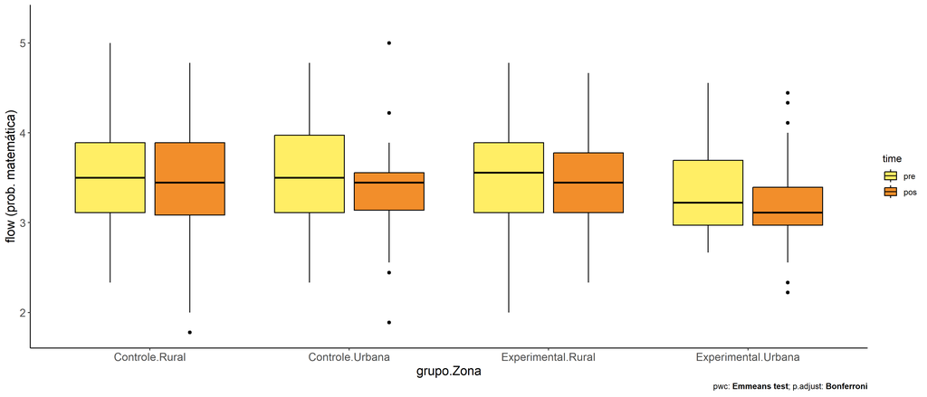

```r
plots[["grupo:Zona"]] + ggplot2::ylab("flow (prob. matemática)")
```

### Checking linearity assumption

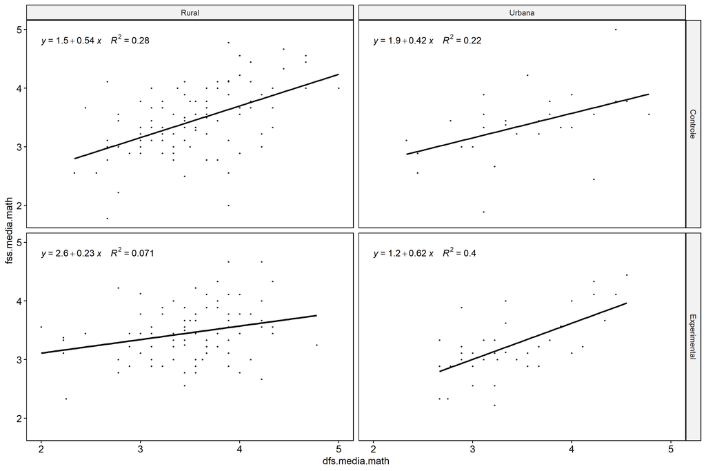

```r
ggscatter(wdat, x = "dfs.media.math", y = "fss.media.math", size = 0.5,
          facet.by = c("grupo","Zona"), add = "reg.line")+
  stat_regline_equation(
    aes(label =  paste(..eq.label.., ..rr.label.., sep = "~~~~"))
  )
```

### Checking normality and homogeneity

```r
res <- augment(lm(fss.media.math ~ dfs.media.math + grupo*Zona, data = wdat))
```

```r
shapiro_test(res$.resid)
```

```
## # A tibble: 1 × 3
##   variable   statistic p.value
##   <chr>          <dbl>   <dbl>
## 1 res$.resid     0.993   0.311
```

```r
levene_test(res, .resid ~ grupo*Zona)
```

```
## # A tibble: 1 × 4
##     df1   df2 statistic     p
##   <int> <int>     <dbl> <dbl>
## 1     3   259     0.517 0.671
```

# ANCOVA and Pairwise for two factors **grupo:Cor.Raca**

## Without remove non-normal data

```r
pdat = remove_group_data(dat[!is.na(dat[["grupo"]]) & !is.na(dat[["Cor.Raca"]]),], "fss.media.math", c("grupo","Cor.Raca"))
pdat.long <- rbind(pdat[,c("id","grupo","Cor.Raca")], pdat[,c("id","grupo","Cor.Raca")])
pdat.long[["time"]] <- c(rep("pre", nrow(pdat)), rep("pos", nrow(pdat)))
pdat.long[["time"]] <- factor(pdat.long[["time"]], c("pre","pos"))
pdat.long[["flow.math"]] <- c(pdat[["dfs.media.math"]], pdat[["fss.media.math"]])

aov = anova_test(pdat, fss.media.math ~ dfs.media.math + grupo*Cor.Raca)
laov[["grupo:Cor.Raca"]] <- get_anova_table(aov)
```

```r
pwcs <- list()
pwcs[["Cor.Raca"]] <- emmeans_test(
  group_by(pdat, grupo), fss.media.math ~ Cor.Raca,
  covariate = dfs.media.math, p.adjust.method = "bonferroni")
pwcs[["grupo"]] <- emmeans_test(
  group_by(pdat, Cor.Raca), fss.media.math ~ grupo,
  covariate = dfs.media.math, p.adjust.method = "bonferroni")

pwc <- plyr::rbind.fill(pwcs[["grupo"]], pwcs[["Cor.Raca"]])
pwc <- pwc[,c("grupo","Cor.Raca", colnames(pwc)[!colnames(pwc) %in% c("grupo","Cor.Raca")])]
```

```r
pwc.long <- emmeans_test(dplyr::group_by_at(pdat.long, c("grupo","Cor.Raca")),
                         flow.math ~ time,
                         p.adjust.method = "bonferroni")
lpwc[["grupo:Cor.Raca"]] <- plyr::rbind.fill(pwc, pwc.long)
```

```r
ds <- get.descriptives(pdat, "fss.media.math", c("grupo","Cor.Raca"), covar = "dfs.media.math")
ds <- merge(ds[ds$variable != "dfs.media.math",],
            ds[ds$variable == "dfs.media.math", !colnames(ds) %in% c("variable")],
            by = c("grupo","Cor.Raca"), all.x = T, suffixes = c("", ".dfs.media.math"))
ds <- merge(get_emmeans(pwcs[["grupo"]]), ds, by = c("grupo","Cor.Raca"), suffixes = c(".emms", ""))
ds <- ds[,c("grupo","Cor.Raca","n","mean.dfs.media.math","se.dfs.media.math","mean","se","emmean","se.emms")]

colnames(ds) <- c("grupo","Cor.Raca", "N", paste0(c("M","SE")," (pre)"),
                  paste0(c("M","SE"), " (unadj)"), paste0(c("M", "SE"), " (adj)"))

lemms[["grupo:Cor.Raca"]] <- ds
```

## Computing ANCOVA and PairWise After removing non-normal data (OK)

```r
wdat = pdat

res = residuals(lm(fss.media.math ~ dfs.media.math + grupo*Cor.Raca, data = wdat))
non.normal = getNonNormal(res, wdat$id, plimit = 0.05)

wdat = wdat[!wdat$id %in% non.normal,]

wdat.long <- rbind(wdat[,c("id","grupo","Cor.Raca")], wdat[,c("id","grupo","Cor.Raca")])
wdat.long[["time"]] <- c(rep("pre", nrow(wdat)), rep("pos", nrow(wdat)))
wdat.long[["time"]] <- factor(wdat.long[["time"]], c("pre","pos"))
wdat.long[["flow.math"]] <- c(wdat[["dfs.media.math"]], wdat[["fss.media.math"]])


ldat[["grupo:Cor.Raca"]] = wdat

(non.normal)
```

[output not shown]

```r
aov = anova_test(wdat, fss.media.math ~ dfs.media.math + grupo*Cor.Raca)
laov[["grupo:Cor.Raca"]] <- merge(get_anova_table(aov), laov[["grupo:Cor.Raca"]], by="Effect", suffixes = c("","'"))

(df = get_anova_table(aov))
```

```
## ANOVA Table (type II tests)
##
##           Effect DFn DFd      F        p p<.05      ges
## 1 dfs.media.math   1 135 27.928 4.93e-07     * 0.171000
## 2          grupo   1 135  0.061 8.05e-01       0.000452
## 3       Cor.Raca   2 135  1.695 1.87e-01       0.025000
## 4 grupo:Cor.Raca   1 135  0.145 7.04e-01       0.001000
```

| Effect | DFn | DFd | F | p | p<.05 | ges |
| --- | --- | --- | --- | --- | --- | --- |
| dfs.media.math | 1 | 135 | 27.928 | 0.000 | * | 0.171 |
| grupo | 1 | 135 | 0.061 | 0.805 |  | 0.000 |
| Cor.Raca | 2 | 135 | 1.695 | 0.187 |  | 0.025 |
| grupo:Cor.Raca | 1 | 135 | 0.145 | 0.704 |  | 0.001 |

```r
pwcs <- list()
pwcs[["Cor.Raca"]] <- emmeans_test(
  group_by(wdat, grupo), fss.media.math ~ Cor.Raca,
  covariate = dfs.media.math, p.adjust.method = "bonferroni")
pwcs[["grupo"]] <- emmeans_test(
  group_by(wdat, Cor.Raca), fss.media.math ~ grupo,
  covariate = dfs.media.math, p.adjust.method = "bonferroni")

pwc <- plyr::rbind.fill(pwcs[["grupo"]], pwcs[["Cor.Raca"]])
pwc <- pwc[,c("grupo","Cor.Raca", colnames(pwc)[!colnames(pwc) %in% c("grupo","Cor.Raca")])]
```

| grupo | Cor.Raca | term | .y. | group1 | group2 | df | statistic | p | p.adj | p.adj.signif |
| --- | --- | --- | --- | --- | --- | --- | --- | --- | --- | --- |
|  | Branca | dfs.media.math*grupo | fss.media.math | Controle | Experimental | 135 | 0.454 | 0.651 | 0.651 | ns |
|  | Indígena | dfs.media.math*grupo | fss.media.math | Controle | Experimental |  |  |  |  |  |
|  | Parda | dfs.media.math*grupo | fss.media.math | Controle | Experimental | 135 | 0.003 | 0.997 | 0.997 | ns |
| Controle |  | dfs.media.math*Cor.Raca | fss.media.math | Branca | Indígena |  |  |  |  |  |
| Controle |  | dfs.media.math*Cor.Raca | fss.media.math | Branca | Parda | 135 | 1.245 | 0.215 | 0.215 | ns |
| Controle |  | dfs.media.math*Cor.Raca | fss.media.math | Indígena | Parda |  |  |  |  |  |
| Experimental |  | dfs.media.math*Cor.Raca | fss.media.math | Branca | Indígena | 135 | 1.400 | 0.164 | 0.492 | ns |
| Experimental |  | dfs.media.math*Cor.Raca | fss.media.math | Branca | Parda | 135 | 0.646 | 0.519 | 1.000 | ns |
| Experimental |  | dfs.media.math*Cor.Raca | fss.media.math | Indígena | Parda | 135 | -1.047 | 0.297 | 0.891 | ns |

```r
pwc.long <- emmeans_test(dplyr::group_by_at(wdat.long, c("grupo","Cor.Raca")),
                         flow.math ~ time,
                         p.adjust.method = "bonferroni")
lpwc[["grupo:Cor.Raca"]] <- merge(plyr::rbind.fill(pwc, pwc.long), lpwc[["grupo:Cor.Raca"]], by=c("grupo","Cor.Raca","term",".y.","group1","group2"), suffixes = c("","'"))
```

| grupo | Cor.Raca | term | .y. | group1 | group2 | df | statistic | p | p.adj | p.adj.signif |
| --- | --- | --- | --- | --- | --- | --- | --- | --- | --- | --- |
| Controle | Branca | time | flow.math | pre | pos | 272 | -0.371 | 0.711 | 0.711 | ns |
| Controle | Indígena | time | flow.math | pre | pos |  |  |  |  |  |
| Controle | Parda | time | flow.math | pre | pos | 272 | 0.792 | 0.429 | 0.429 | ns |
| Experimental | Branca | time | flow.math | pre | pos | 272 | -0.041 | 0.967 | 0.967 | ns |
| Experimental | Indígena | time | flow.math | pre | pos | 272 | 1.366 | 0.173 | 0.173 | ns |
| Experimental | Parda | time | flow.math | pre | pos | 272 | -0.042 | 0.966 | 0.966 | ns |

```r
ds <- get.descriptives(wdat, "fss.media.math", c("grupo","Cor.Raca"), covar = "dfs.media.math")
ds <- merge(ds[ds$variable != "dfs.media.math",],
            ds[ds$variable == "dfs.media.math", !colnames(ds) %in% c("variable")],
            by = c("grupo","Cor.Raca"), all.x = T, suffixes = c("", ".dfs.media.math"))
ds <- merge(get_emmeans(pwcs[["grupo"]]), ds, by = c("grupo","Cor.Raca"), suffixes = c(".emms", ""))
ds <- ds[,c("grupo","Cor.Raca","n","mean.dfs.media.math","se.dfs.media.math","mean","se","emmean","se.emms")]

colnames(ds) <- c("grupo","Cor.Raca", "N", paste0(c("M","SE")," (pre)"),
                  paste0(c("M","SE"), " (unadj)"), paste0(c("M", "SE"), " (adj)"))

lemms[["grupo:Cor.Raca"]] <- merge(ds, lemms[["grupo:Cor.Raca"]], by=c("grupo","Cor.Raca"), suffixes = c("","'"))
```

| grupo | Cor.Raca | N | M (pre) | SE (pre) | M (unadj) | SE (unadj) | M (adj) | SE (adj) |
| --- | --- | --- | --- | --- | --- | --- | --- | --- |
| Controle | Branca | 20 | 3.489 | 0.151 | 3.550 | 0.122 | 3.530 | 0.103 |
| Controle | Parda | 46 | 3.478 | 0.081 | 3.392 | 0.072 | 3.376 | 0.068 |
| Experimental | Branca | 17 | 3.464 | 0.094 | 3.471 | 0.150 | 3.461 | 0.112 |
| Experimental | Indígena | 13 | 3.544 | 0.106 | 3.265 | 0.103 | 3.223 | 0.128 |
| Experimental | Parda | 45 | 3.330 | 0.080 | 3.334 | 0.073 | 3.376 | 0.069 |